# Отчёт по лабораторной работе: Последовательная RLC-цепь (AC)

Студент

21 Декабрь 2025

# 1. Цель работы

Приобретение навыков сборки и анализа последовательной RLC-цепи в сети переменного тока: измерения напряжений и тока, определение резонансной частоты, построение векторных диаграмм и графиков зависимостей величин от частоты.

# 2. Оборудование и исходные данные

Даны компоненты и приборы: два конденсатора по 22 мкФ, линейный дроссель L = 0.28 Гн с активным сопротивлением (RL = 25 Ом), резистор R = 22 Ом, два мультиметра, измеритель мощности, функциональный генератор.

Ниже приведена таблица измеренных значений, использованная в анализе (величины из задания).

```r
# Исходные данные (из предоставленной таблицы)
df <- tibble(
  f_Hz = c(25, 32, 37, 42, 47, 52, 60),
  U_meas_V = c(6.7, 6.6, 6.6, 6.6, 6.6, 6.6, 6.6),
  I_mA = c(71, 104, 126, 135, 127, 112, 90),
  U_R_V = c(1.5, 2.2, 2.7, 2.9, 2.7, 2.4, 1.9),
  U_L_V = c(3.4, 6.3, 8.8, 10.6, 11.2, 10.8, 10.0),
  U_C_V = c(8.9, 10.3, 10.8, 10.3, 8.7, 7.0, 4.9),
  P_meas_W = c(0.24, 0.51, 0.76, 0.87, 0.77, 0.6, 0.4),
  Q_meas_VAr = c(-0.38, -0.42, -0.29, 0.0, 0.25, 0.38, 0.41),
  phi_meas_deg = c(-58, -39, -21, 0, 18, 32, 46)
)

# Дополнительные преобразования
df <- df %>% mutate(
  I_A = I_mA / 1000,
  # суммарное напряжение по векторной сумме: UR (действительная) и разность (UL-UC) (мнимая)
  U_calc_V = sqrt(U_R_V^2 + (U_L_V - U_C_V)^2),
  phi_calc_rad = atan2(U_L_V - U_C_V, U_R_V),
  phi_calc_deg = phi_calc_rad * 180 / pi,
  P_calc_W = U_meas_V * I_A * cos(phi_calc_rad),
  Q_calc_VAr = U_meas_V * I_A * sin(phi_calc_rad),
  U_diff_pct = 100 * (U_calc_V - U_meas_V) / U_meas_V,
  phi_diff_deg = phi_calc_deg - phi_meas_deg
)

# Показать таблицу
print(df %>% select(f_Hz, U_meas_V, I_mA, U_R_V, U_L_V, U_C_V, P_meas_W, Q_meas_VAr, phi_meas_deg, U_calc_V, phi_calc_deg, P_calc_W, Q_calc_VAr, U_diff_pct, phi_diff_deg) %>%
        mutate_if(is.numeric, ~round(., 3)))
```

```
## # A tibble: 7 × 15
##    f_Hz U_meas_V  I_mA U_R_V U_L_V U_C_V P_meas_W Q_meas_VAr phi_meas_deg
##   <dbl>    <dbl> <dbl> <dbl> <dbl> <dbl>    <dbl>      <dbl>        <dbl>
## 1    25      6.7    71   1.5   3.4   8.9     0.24      -0.38          -58
## 2    32      6.6   104   2.2   6.3  10.3     0.51      -0.42          -39
## 3    37      6.6   126   2.7   8.8  10.8     0.76      -0.29          -21
## 4    42      6.6   135   2.9  10.6  10.3     0.87       0               0
## 5    47      6.6   127   2.7  11.2   8.7     0.77       0.25           18
## 6    52      6.6   112   2.4  10.8   7       0.6        0.38           32
## 7    60      6.6    90   1.9  10     4.9     0.4        0.41           46
## # ℹ 6 more variables: U_calc_V <dbl>, phi_calc_deg <dbl>, P_calc_W <dbl>,
## #   Q_calc_VAr <dbl>, U_diff_pct <dbl>, phi_diff_deg <dbl>
```

# 3. Обработка данных и графики

## 3.1 Ток как функция частоты

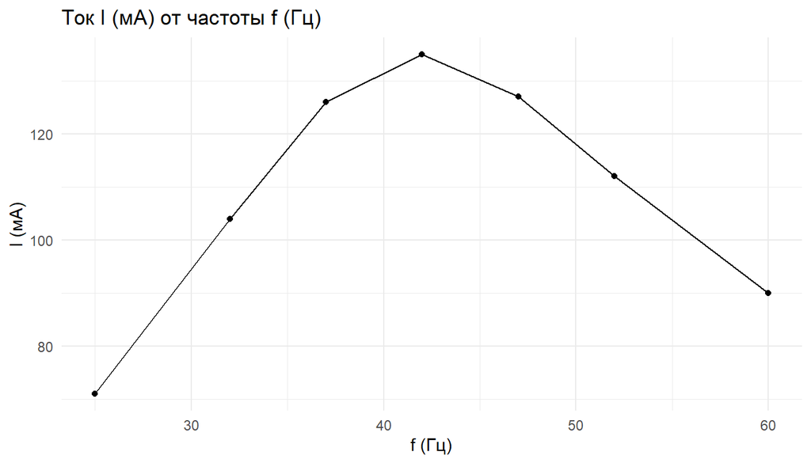

```r
ggplot(df, aes(x = f_Hz, y = I_mA)) +
  geom_line() + geom_point() +
  labs(title = "Ток I (мА) от частоты f (Гц)", x = "f (Гц)", y = "I (мА)") +
  theme_minimal()
```

## 3.2 Напряжения U_L и U_C от частоты

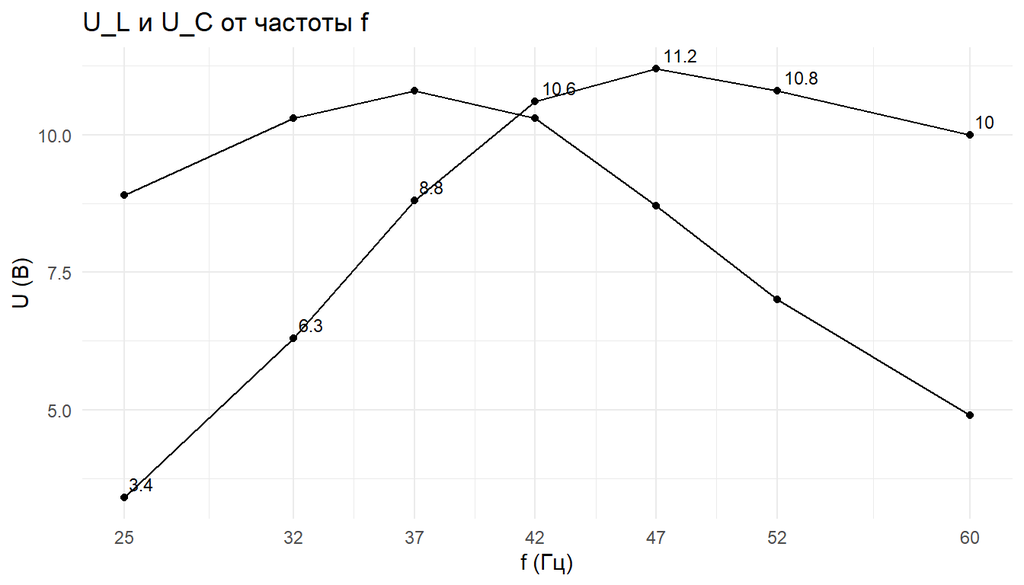

```r
ggplot(df, aes(x = f_Hz)) +
  geom_line(aes(y = U_L_V)) + geom_point(aes(y = U_L_V)) +
  geom_line(aes(y = U_C_V)) + geom_point(aes(y = U_C_V)) +
  labs(title = "U_L и U_C от частоты f", x = "f (Гц)", y = "U (В)") +
  scale_x_continuous(breaks = df$f_Hz) +
  theme_minimal() +
  geom_text(aes(y = U_L_V, label = round(U_L_V,1)), hjust = -0.2, vjust = -0.5, size = 3)
```

## 3.3 Фазовый угол: измеренный vs рассчитанный

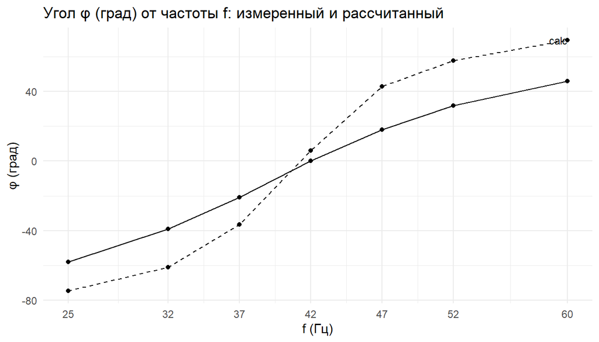

```r
ggplot(df, aes(x = f_Hz)) +
  geom_line(aes(y = phi_meas_deg), color = NULL) + geom_point(aes(y = phi_meas_deg)) +
  geom_line(aes(y = phi_calc_deg), linetype = "dashed") + geom_point(aes(y = phi_calc_deg)) +
  labs(title = "Угол φ (град) от частоты f: измеренный и рассчитанный", x = "f (Гц)", y = "φ (град)") +
  scale_x_continuous(breaks = df$f_Hz) +
  theme_minimal() +
  annotate("text", x = 60, y = df$phi_calc_deg[nrow(df)], label = "calc", hjust = 1, size = 3)
```

# 4. Фазорные (векторные) диаграммы

Векторные диаграммы построены при трёх типичных частотах: ниже резонанса (37 Гц), в резонансе (42 Гц), и выше резонанса (52 Гц). За опорный вектор принимаем напряжение на сопротивлении $U_R$ (совпадает по фазе с током). Векторы $U_L$ направлены вверх (+j), $U_C$ вниз (−j).

[figure not shown]

```r
# Функция для построения фазорной диаграммы
plot_phasor <- function(row, scale = 1) {
  UR <- row$U_R_V
  UL <- row$U_L_V
  UC <- row$U_C_V
  Ux <- UR
  Uy <- UL - UC
  Utot <- sqrt(Ux^2 + Uy^2)
  phi_deg <- row$phi_calc_deg
  df_ph <- tibble(x = c(0, UR, 0, 0), y = c(0, 0, UL, -UC),
                  lab = c("origin", paste0("U_R = ", round(UR,2), " V"), paste0("U_L = ", round(UL,2), " V"), paste0("U_C = ", round(UC,2), " V")),
                  xend = c(UR, UR, 0, 0), yend = c(0, 0, UL, -UC))
  ggplot() +
    geom_segment(aes(x = 0, y = 0, xend = UR, yend = 0), arrow = arrow(length = unit(0.2, "cm"))) +
    geom_segment(aes(x = 0, y = 0, xend = 0, yend = UL), arrow = arrow(length = unit(0.2, "cm"))) +
    geom_segment(aes(x = 0, y = 0, xend = 0, yend = -UC), arrow = arrow(length = unit(0.2, "cm"))) +
    geom_segment(aes(x = 0, y = 0, xend = Ux, yend = Uy), arrow = arrow(length = unit(0.25, "cm")), color = "black") +
    geom_text(aes(x = UR, y = 0), label = paste0("U_R\n", round(UR,2), " V"), hjust = -0.05, vjust = -0.5) +
    geom_text(aes(x = 0, y = UL), label = paste0("U_L\n", round(UL,2), " V"), hjust = 0.1, vjust = 0) +
    geom_text(aes(x = 0, y = -UC), label = paste0("U_C\n", round(UC,2), " V"), hjust = 0.1, vjust = 1) +
    geom_text(aes(x = Ux*0.6, y = Uy*0.6), label = paste0("U_tot = ", round(Utot,2), " V\nφ = ", round(phi_deg,1), "°")) +
    labs(title = paste0("Фазорная диаграмма при f = ", row$f_Hz, " Гц (масштаб: 1 В = 1 ед.)"), x = "Действительная, В", y = "Мнимая, В") +
    coord_fixed() +
    theme_minimal()
}

# Выбрать строки
rows <- df %>% filter(f_Hz %in% c(37, 42, 52))
plots <- purrr::map(1:nrow(rows), ~plot_phasor(rows[.x, ]))
plots[[1]]
```

[figure not shown]

```r
plots[[2]]
```

[figure not shown]

```r
plots[[3]]
```